# Optimal Treatment Analysis

## Outcome Variable

**Outcome Variable:** ever_wasted

## Predictor Variables

**Intervention Variable:** earlybf

**Adjustment Set:**

- arm
- sex
- W_mage
- meducyrs
- feducyrs
- hhwealth_quart
- W_mhtcm
- vagbrth
- W_birthwt
- W_birthlen
- W_nrooms
- brthmon
- W_parity
- impfloor
- impsan
- safeh20
- delta_W_mage
- delta_meducyrs
- delta_feducyrs
- delta_hhwealth_quart
- delta_W_mhtcm
- delta_vagbrth
- delta_W_birthwt
- delta_W_birthlen
- delta_W_nrooms
- delta_brthmon
- delta_W_parity
- delta_impfloor
- delta_impsan
- delta_safeh20

## Stratifying Variables

The analysis was stratified on these variable(s):

- agecat
- studyid
- country

## Data Summary

| agecat | studyid | country | earlybf | ever_wasted | n_cell | n |
| --- | --- | --- | --- | --- | --- | --- |
| 0-24 months (no birth wast) | ki0047075b-MAL-ED | BANGLADESH | 1 | 0 | 127 | 260 |
| 0-24 months (no birth wast) | ki0047075b-MAL-ED | BANGLADESH | 1 | 1 | 33 | 260 |
| 0-24 months (no birth wast) | ki0047075b-MAL-ED | BANGLADESH | 0 | 0 | 76 | 260 |
| 0-24 months (no birth wast) | ki0047075b-MAL-ED | BANGLADESH | 0 | 1 | 24 | 260 |
| 0-24 months (no birth wast) | ki0047075b-MAL-ED | BRAZIL | 1 | 0 | 101 | 229 |
| 0-24 months (no birth wast) | ki0047075b-MAL-ED | BRAZIL | 1 | 1 | 4 | 229 |
| 0-24 months (no birth wast) | ki0047075b-MAL-ED | BRAZIL | 0 | 0 | 116 | 229 |
| 0-24 months (no birth wast) | ki0047075b-MAL-ED | BRAZIL | 0 | 1 | 8 | 229 |
| 0-24 months (no birth wast) | ki0047075b-MAL-ED | INDIA | 1 | 0 | 90 | 242 |
| 0-24 months (no birth wast) | ki0047075b-MAL-ED | INDIA | 1 | 1 | 55 | 242 |
| 0-24 months (no birth wast) | ki0047075b-MAL-ED | INDIA | 0 | 0 | 63 | 242 |
| 0-24 months (no birth wast) | ki0047075b-MAL-ED | INDIA | 0 | 1 | 34 | 242 |
| 0-24 months (no birth wast) | ki0047075b-MAL-ED | NEPAL | 1 | 0 | 78 | 238 |
| 0-24 months (no birth wast) | ki0047075b-MAL-ED | NEPAL | 1 | 1 | 18 | 238 |
| 0-24 months (no birth wast) | ki0047075b-MAL-ED | NEPAL | 0 | 0 | 115 | 238 |
| 0-24 months (no birth wast) | ki0047075b-MAL-ED | NEPAL | 0 | 1 | 27 | 238 |
| 0-24 months (no birth wast) | ki0047075b-MAL-ED | PERU | 1 | 0 | 204 | 299 |
| 0-24 months (no birth wast) | ki0047075b-MAL-ED | PERU | 1 | 1 | 19 | 299 |
| 0-24 months (no birth wast) | ki0047075b-MAL-ED | PERU | 0 | 0 | 75 | 299 |
| 0-24 months (no birth wast) | ki0047075b-MAL-ED | PERU | 0 | 1 | 1 | 299 |
| 0-24 months (no birth wast) | ki0047075b-MAL-ED | SOUTH AFRICA | 1 | 0 | 147 | 288 |
| 0-24 months (no birth wast) | ki0047075b-MAL-ED | SOUTH AFRICA | 1 | 1 | 30 | 288 |
| 0-24 months (no birth wast) | ki0047075b-MAL-ED | SOUTH AFRICA | 0 | 0 | 97 | 288 |
| 0-24 months (no birth wast) | ki0047075b-MAL-ED | SOUTH AFRICA | 0 | 1 | 14 | 288 |
| 0-24 months (no birth wast) | ki0047075b-MAL-ED | TANZANIA, UNITED REPUBLIC OF | 1 | 0 | 189 | 261 |
| 0-24 months (no birth wast) | ki0047075b-MAL-ED | TANZANIA, UNITED REPUBLIC OF | 1 | 1 | 27 | 261 |
| 0-24 months (no birth wast) | ki0047075b-MAL-ED | TANZANIA, UNITED REPUBLIC OF | 0 | 0 | 42 | 261 |
| 0-24 months (no birth wast) | ki0047075b-MAL-ED | TANZANIA, UNITED REPUBLIC OF | 0 | 1 | 3 | 261 |
| 0-24 months (no birth wast) | ki1000109-EE | PAKISTAN | 1 | 0 | 44 | 377 |
| 0-24 months (no birth wast) | ki1000109-EE | PAKISTAN | 1 | 1 | 24 | 377 |

[output cut: 138 more lines]

The following strata were considered:

- agecat: 0-24 months (no birth wast), studyid: ki0047075b-MAL-ED, country: BANGLADESH
- agecat: 0-24 months (no birth wast), studyid: ki0047075b-MAL-ED, country: BRAZIL
- agecat: 0-24 months (no birth wast), studyid: ki0047075b-MAL-ED, country: INDIA
- agecat: 0-24 months (no birth wast), studyid: ki0047075b-MAL-ED, country: NEPAL
- agecat: 0-24 months (no birth wast), studyid: ki0047075b-MAL-ED, country: PERU
- agecat: 0-24 months (no birth wast), studyid: ki0047075b-MAL-ED, country: SOUTH AFRICA
- agecat: 0-24 months (no birth wast), studyid: ki0047075b-MAL-ED, country: TANZANIA, UNITED REPUBLIC OF
- agecat: 0-24 months (no birth wast), studyid: ki1000109-EE, country: PAKISTAN
- agecat: 0-24 months (no birth wast), studyid: ki1000304b-SAS-CompFeed, country: INDIA
- agecat: 0-24 months (no birth wast), studyid: ki1017093c-NIH-Crypto, country: BANGLADESH
- agecat: 0-24 months (no birth wast), studyid: ki1113344-GMS-Nepal, country: NEPAL
- agecat: 0-24 months (no birth wast), studyid: ki1126311-ZVITAMBO, country: ZIMBABWE
- agecat: 0-24 months (no birth wast), studyid: kiGH5241-JiVitA-3, country: BANGLADESH
- agecat: 0-24 months (no birth wast), studyid: kiGH5241-JiVitA-4, country: BANGLADESH
- agecat: 0-6 months (no birth wast), studyid: ki0047075b-MAL-ED, country: BANGLADESH
- agecat: 0-6 months (no birth wast), studyid: ki0047075b-MAL-ED, country: BRAZIL
- agecat: 0-6 months (no birth wast), studyid: ki0047075b-MAL-ED, country: INDIA
- agecat: 0-6 months (no birth wast), studyid: ki0047075b-MAL-ED, country: NEPAL
- agecat: 0-6 months (no birth wast), studyid: ki0047075b-MAL-ED, country: PERU
- agecat: 0-6 months (no birth wast), studyid: ki0047075b-MAL-ED, country: SOUTH AFRICA
- agecat: 0-6 months (no birth wast), studyid: ki0047075b-MAL-ED, country: TANZANIA, UNITED REPUBLIC OF
- agecat: 0-6 months (no birth wast), studyid: ki1000109-EE, country: PAKISTAN
- agecat: 0-6 months (no birth wast), studyid: ki1000304b-SAS-CompFeed, country: INDIA
- agecat: 0-6 months (no birth wast), studyid: ki1017093c-NIH-Crypto, country: BANGLADESH
- agecat: 0-6 months (no birth wast), studyid: ki1113344-GMS-Nepal, country: NEPAL
- agecat: 0-6 months (no birth wast), studyid: ki1126311-ZVITAMBO, country: ZIMBABWE
- agecat: 0-6 months (no birth wast), studyid: kiGH5241-JiVitA-3, country: BANGLADESH
- agecat: 0-6 months (no birth wast), studyid: kiGH5241-JiVitA-4, country: BANGLADESH
- agecat: 6-24 months, studyid: ki0047075b-MAL-ED, country: BANGLADESH
- agecat: 6-24 months, studyid: ki0047075b-MAL-ED, country: BRAZIL
- agecat: 6-24 months, studyid: ki0047075b-MAL-ED, country: INDIA
- agecat: 6-24 months, studyid: ki0047075b-MAL-ED, country: NEPAL
- agecat: 6-24 months, studyid: ki0047075b-MAL-ED, country: PERU
- agecat: 6-24 months, studyid: ki0047075b-MAL-ED, country: SOUTH AFRICA
- agecat: 6-24 months, studyid: ki0047075b-MAL-ED, country: TANZANIA, UNITED REPUBLIC OF
- agecat: 6-24 months, studyid: ki1000109-EE, country: PAKISTAN
- agecat: 6-24 months, studyid: ki1000304b-SAS-CompFeed, country: INDIA
- agecat: 6-24 months, studyid: ki1017093c-NIH-Crypto, country: BANGLADESH
- agecat: 6-24 months, studyid: ki1113344-GMS-Nepal, country: NEPAL
- agecat: 6-24 months, studyid: ki1126311-ZVITAMBO, country: ZIMBABWE
- agecat: 6-24 months, studyid: kiGH5241-JiVitA-3, country: BANGLADESH
- agecat: 6-24 months, studyid: kiGH5241-JiVitA-4, country: BANGLADESH

### Dropped Strata

Some strata were dropped due to rare outcomes:

- agecat: 0-24 months (no birth wast), studyid: ki0047075b-MAL-ED, country: BRAZIL
- agecat: 0-24 months (no birth wast), studyid: ki0047075b-MAL-ED, country: PERU
- agecat: 0-24 months (no birth wast), studyid: ki0047075b-MAL-ED, country: TANZANIA, UNITED REPUBLIC OF
- agecat: 0-24 months (no birth wast), studyid: ki1000304b-SAS-CompFeed, country: INDIA
- agecat: 0-6 months (no birth wast), studyid: ki0047075b-MAL-ED, country: BRAZIL
- agecat: 0-6 months (no birth wast), studyid: ki0047075b-MAL-ED, country: PERU
- agecat: 0-6 months (no birth wast), studyid: ki0047075b-MAL-ED, country: SOUTH AFRICA
- agecat: 0-6 months (no birth wast), studyid: ki0047075b-MAL-ED, country: TANZANIA, UNITED REPUBLIC OF
- agecat: 0-6 months (no birth wast), studyid: ki1000304b-SAS-CompFeed, country: INDIA
- agecat: 0-6 months (no birth wast), studyid: ki1017093c-NIH-Crypto, country: BANGLADESH
- agecat: 6-24 months, studyid: ki0047075b-MAL-ED, country: BRAZIL
- agecat: 6-24 months, studyid: ki0047075b-MAL-ED, country: PERU
- agecat: 6-24 months, studyid: ki0047075b-MAL-ED, country: TANZANIA, UNITED REPUBLIC OF
- agecat: 6-24 months, studyid: ki1000304b-SAS-CompFeed, country: INDIA
- agecat: 6-24 months, studyid: kiGH5241-JiVitA-3, country: BANGLADESH

## Methods Detail

We’re interested in the causal parameters $E[Y_a]$ for all values of $a \in \mathcal{A}$. These parameters represent the mean outcome if, possibly contrary to fact, we intervened to set all units to have $A=a$. Under the randomization and positivity assumptions, these are identified by the statistical parameters $\psi_a=E_W[E_{Y|A,W}(Y|A=a,W)]$. In addition, we’re interested in the mean of $Y$, $E[Y]$ under no intervention (the observed mean). We will estimate these parameters by using SuperLearner to fit the relevant likelihood factors – $E_{Y|A,W}(Y|A=a,W)$ and $p(A=a|W)$, and then updating our likelihood fit using a joint TMLE.

For unadjusted analyses ($W=\{\}$), initial likelihoods were estimated using Lrnr_glm to estimate the simple $E(Y|A)$ and Lrnr_mean to estimate $p(A)$. For adjusted analyses, a small library containing Lrnr_glmnet, Lrnr_xgboost, and Lrnr_mean was used.

Having estimated these parameters, we will then use the delta method to estimate relative risks and attributable risks relative to a prespecified baseline level of $A$.

# Results Detail

## Results Plots

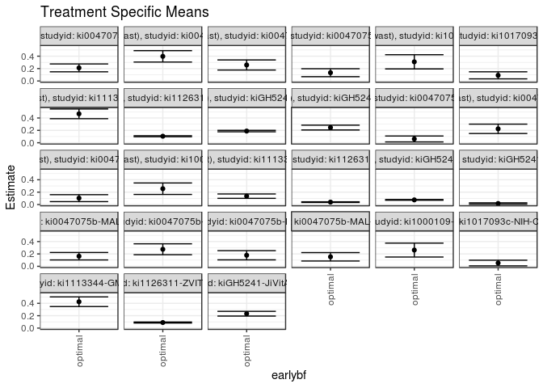

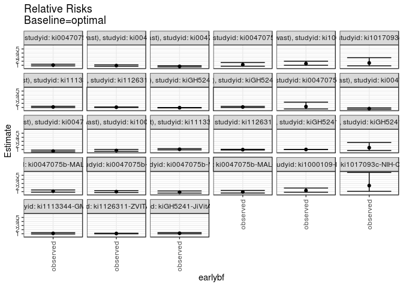

## Results Table

### Parameter: TSM

| agecat | studyid | country | intervention_level | baseline_level | estimate | ci_lower | ci_upper |
| --- | --- | --- | --- | --- | --- | --- | --- |
| 0-24 months (no birth wast) | ki0047075b-MAL-ED | BANGLADESH | optimal | NA | 0.2113785 | 0.1478857 | 0.2748713 |
| 0-24 months (no birth wast) | ki0047075b-MAL-ED | INDIA | optimal | NA | 0.3973087 | 0.3051809 | 0.4894365 |
| 0-24 months (no birth wast) | ki0047075b-MAL-ED | NEPAL | optimal | NA | 0.2581266 | 0.1765373 | 0.3397158 |
| 0-24 months (no birth wast) | ki0047075b-MAL-ED | SOUTH AFRICA | optimal | NA | 0.1334271 | 0.0692250 | 0.1976291 |
| 0-24 months (no birth wast) | ki1000109-EE | PAKISTAN | optimal | NA | 0.3092119 | 0.1945192 | 0.4239047 |
| 0-24 months (no birth wast) | ki1017093c-NIH-Crypto | BANGLADESH | optimal | NA | 0.0911240 | 0.0340834 | 0.1481646 |
| 0-24 months (no birth wast) | ki1113344-GMS-Nepal | NEPAL | optimal | NA | 0.4669740 | 0.3884537 | 0.5454944 |
| 0-24 months (no birth wast) | ki1126311-ZVITAMBO | ZIMBABWE | optimal | NA | 0.1054615 | 0.0973251 | 0.1135978 |
| 0-24 months (no birth wast) | kiGH5241-JiVitA-3 | BANGLADESH | optimal | NA | 0.1887825 | 0.1768177 | 0.2007472 |
| 0-24 months (no birth wast) | kiGH5241-JiVitA-4 | BANGLADESH | optimal | NA | 0.2449058 | 0.2060274 | 0.2837843 |
| 0-6 months (no birth wast) | ki0047075b-MAL-ED | BANGLADESH | optimal | NA | 0.0611579 | 0.0134554 | 0.1088604 |
| 0-6 months (no birth wast) | ki0047075b-MAL-ED | INDIA | optimal | NA | 0.2247905 | 0.1490002 | 0.3005808 |
| 0-6 months (no birth wast) | ki0047075b-MAL-ED | NEPAL | optimal | NA | 0.1032722 | 0.0471894 | 0.1593549 |
| 0-6 months (no birth wast) | ki1000109-EE | PAKISTAN | optimal | NA | 0.2552831 | 0.1626737 | 0.3478925 |
| 0-6 months (no birth wast) | ki1113344-GMS-Nepal | NEPAL | optimal | NA | 0.1354303 | 0.1001271 | 0.1707335 |
| 0-6 months (no birth wast) | ki1126311-ZVITAMBO | ZIMBABWE | optimal | NA | 0.0389713 | 0.0335760 | 0.0443665 |
| 0-6 months (no birth wast) | kiGH5241-JiVitA-3 | BANGLADESH | optimal | NA | 0.0750334 | 0.0696177 | 0.0804491 |
| 0-6 months (no birth wast) | kiGH5241-JiVitA-4 | BANGLADESH | optimal | NA | 0.0168480 | 0.0064157 | 0.0272803 |
| 6-24 months | ki0047075b-MAL-ED | BANGLADESH | optimal | NA | 0.1629818 | 0.1029335 | 0.2230301 |
| 6-24 months | ki0047075b-MAL-ED | INDIA | optimal | NA | 0.2750535 | 0.1871431 | 0.3629639 |
| 6-24 months | ki0047075b-MAL-ED | NEPAL | optimal | NA | 0.1784458 | 0.1042762 | 0.2526154 |
| 6-24 months | ki0047075b-MAL-ED | SOUTH AFRICA | optimal | NA | 0.1532341 | 0.0853166 | 0.2211516 |
| 6-24 months | ki1000109-EE | PAKISTAN | optimal | NA | 0.2622196 | 0.1500350 | 0.3744042 |
| 6-24 months | ki1017093c-NIH-Crypto | BANGLADESH | optimal | NA | 0.0530981 | 0.0075604 | 0.0986358 |
| 6-24 months | ki1113344-GMS-Nepal | NEPAL | optimal | NA | 0.4256743 | 0.3476409 | 0.5037077 |
| 6-24 months | ki1126311-ZVITAMBO | ZIMBABWE | optimal | NA | 0.0898430 | 0.0815067 | 0.0981794 |
| 6-24 months | kiGH5241-JiVitA-4 | BANGLADESH | optimal | NA | 0.2322841 | 0.1943379 | 0.2702304 |

### Parameter: E(Y)

| agecat | studyid | country | intervention_level | baseline_level | estimate | ci_lower | ci_upper |
| --- | --- | --- | --- | --- | --- | --- | --- |
| 0-24 months (no birth wast) | ki0047075b-MAL-ED | BANGLADESH | observed | NA | 0.2192308 | 0.1688447 | 0.2696168 |
| 0-24 months (no birth wast) | ki0047075b-MAL-ED | INDIA | observed | NA | 0.3677686 | 0.3068900 | 0.4286472 |
| 0-24 months (no birth wast) | ki0047075b-MAL-ED | NEPAL | observed | NA | 0.1890756 | 0.1392237 | 0.2389275 |
| 0-24 months (no birth wast) | ki0047075b-MAL-ED | SOUTH AFRICA | observed | NA | 0.1527778 | 0.1111545 | 0.1944010 |
| 0-24 months (no birth wast) | ki1000109-EE | PAKISTAN | observed | NA | 0.4376658 | 0.3875213 | 0.4878102 |
| 0-24 months (no birth wast) | ki1017093c-NIH-Crypto | BANGLADESH | observed | NA | 0.1432361 | 0.1182149 | 0.1682572 |
| 0-24 months (no birth wast) | ki1113344-GMS-Nepal | NEPAL | observed | NA | 0.5167910 | 0.4744466 | 0.5591355 |
| 0-24 months (no birth wast) | ki1126311-ZVITAMBO | ZIMBABWE | observed | NA | 0.1098365 | 0.1040117 | 0.1156613 |
| 0-24 months (no birth wast) | kiGH5241-JiVitA-3 | BANGLADESH | observed | NA | 0.1743077 | 0.1664913 | 0.1821241 |
| 0-24 months (no birth wast) | kiGH5241-JiVitA-4 | BANGLADESH | observed | NA | 0.2695285 | 0.2427999 | 0.2962571 |
| 0-6 months (no birth wast) | ki0047075b-MAL-ED | BANGLADESH | observed | NA | 0.0733591 | 0.0415449 | 0.1051733 |
| 0-6 months (no birth wast) | ki0047075b-MAL-ED | INDIA | observed | NA | 0.1576763 | 0.1115695 | 0.2037832 |
| 0-6 months (no birth wast) | ki0047075b-MAL-ED | NEPAL | observed | NA | 0.0635593 | 0.0323673 | 0.0947514 |
| 0-6 months (no birth wast) | ki1000109-EE | PAKISTAN | observed | NA | 0.1930295 | 0.1529228 | 0.2331362 |
| 0-6 months (no birth wast) | ki1113344-GMS-Nepal | NEPAL | observed | NA | 0.1420233 | 0.1118164 | 0.1722303 |
| 0-6 months (no birth wast) | ki1126311-ZVITAMBO | ZIMBABWE | observed | NA | 0.0374742 | 0.0337823 | 0.0411660 |
| 0-6 months (no birth wast) | kiGH5241-JiVitA-3 | BANGLADESH | observed | NA | 0.0753879 | 0.0700839 | 0.0806918 |
| 0-6 months (no birth wast) | kiGH5241-JiVitA-4 | BANGLADESH | observed | NA | 0.0242947 | 0.0148797 | 0.0337096 |
| 6-24 months | ki0047075b-MAL-ED | BANGLADESH | observed | NA | 0.1799163 | 0.1311159 | 0.2287168 |
| 6-24 months | ki0047075b-MAL-ED | INDIA | observed | NA | 0.2723404 | 0.2153029 | 0.3293779 |
| 6-24 months | ki0047075b-MAL-ED | NEPAL | observed | NA | 0.1531915 | 0.1070438 | 0.1993392 |
| 6-24 months | ki0047075b-MAL-ED | SOUTH AFRICA | observed | NA | 0.1411765 | 0.0983547 | 0.1839982 |
| 6-24 months | ki1000109-EE | PAKISTAN | observed | NA | 0.3306667 | 0.2829875 | 0.3783458 |
| 6-24 months | ki1017093c-NIH-Crypto | BANGLADESH | observed | NA | 0.1315068 | 0.1069744 | 0.1560393 |
| 6-24 months | ki1113344-GMS-Nepal | NEPAL | observed | NA | 0.4608209 | 0.4185829 | 0.5030589 |
| 6-24 months | ki1126311-ZVITAMBO | ZIMBABWE | observed | NA | 0.0944269 | 0.0885495 | 0.1003044 |
| 6-24 months | kiGH5241-JiVitA-4 | BANGLADESH | observed | NA | 0.2576816 | 0.2314541 | 0.2839091 |

### Parameter: RR

| agecat | studyid | country | intervention_level | baseline_level | estimate | ci_lower | ci_upper |
| --- | --- | --- | --- | --- | --- | --- | --- |
| 0-24 months (no birth wast) | ki0047075b-MAL-ED | BANGLADESH | observed | optimal | 1.0371478 | 0.8538139 | 1.2598479 |
| 0-24 months (no birth wast) | ki0047075b-MAL-ED | INDIA | observed | optimal | 0.9256495 | 0.7702679 | 1.1123753 |
| 0-24 months (no birth wast) | ki0047075b-MAL-ED | NEPAL | observed | optimal | 0.7324919 | 0.5953427 | 0.9012363 |
| 0-24 months (no birth wast) | ki0047075b-MAL-ED | SOUTH AFRICA | observed | optimal | 1.1450284 | 0.7787880 | 1.6835004 |
| 0-24 months (no birth wast) | ki1000109-EE | PAKISTAN | observed | optimal | 1.4154234 | 1.0049009 | 1.9936529 |
| 0-24 months (no birth wast) | ki1017093c-NIH-Crypto | BANGLADESH | observed | optimal | 1.5718810 | 0.8645710 | 2.8578449 |
| 0-24 months (no birth wast) | ki1113344-GMS-Nepal | NEPAL | observed | optimal | 1.1066804 | 0.9604394 | 1.2751888 |
| 0-24 months (no birth wast) | ki1126311-ZVITAMBO | ZIMBABWE | observed | optimal | 1.0414847 | 0.9840534 | 1.1022678 |
| 0-24 months (no birth wast) | kiGH5241-JiVitA-3 | BANGLADESH | observed | optimal | 0.9233256 | 0.8748420 | 0.9744962 |
| 0-24 months (no birth wast) | kiGH5241-JiVitA-4 | BANGLADESH | observed | optimal | 1.1005393 | 0.9692766 | 1.2495780 |
| 0-6 months (no birth wast) | ki0047075b-MAL-ED | BANGLADESH | observed | optimal | 1.1995026 | 0.6302800 | 2.2828053 |
| 0-6 months (no birth wast) | ki0047075b-MAL-ED | INDIA | observed | optimal | 0.7014369 | 0.5592537 | 0.8797684 |
| 0-6 months (no birth wast) | ki0047075b-MAL-ED | NEPAL | observed | optimal | 0.6154545 | 0.4495829 | 0.8425236 |
| 0-6 months (no birth wast) | ki1000109-EE | PAKISTAN | observed | optimal | 0.7561389 | 0.5597369 | 1.0214549 |
| 0-6 months (no birth wast) | ki1113344-GMS-Nepal | NEPAL | observed | optimal | 1.0486823 | 0.9033152 | 1.2174427 |
| 0-6 months (no birth wast) | ki1126311-ZVITAMBO | ZIMBABWE | observed | optimal | 0.9615851 | 0.8712967 | 1.0612296 |
| 0-6 months (no birth wast) | kiGH5241-JiVitA-3 | BANGLADESH | observed | optimal | 1.0047244 | 0.9990348 | 1.0104464 |
| 0-6 months (no birth wast) | kiGH5241-JiVitA-4 | BANGLADESH | observed | optimal | 1.4419889 | 0.7657663 | 2.7153611 |
| 6-24 months | ki0047075b-MAL-ED | BANGLADESH | observed | optimal | 1.1039043 | 0.8654003 | 1.4081400 |
| 6-24 months | ki0047075b-MAL-ED | INDIA | observed | optimal | 0.9901362 | 0.7837043 | 1.2509434 |
| 6-24 months | ki0047075b-MAL-ED | NEPAL | observed | optimal | 0.8584761 | 0.6343700 | 1.1617528 |
| 6-24 months | ki0047075b-MAL-ED | SOUTH AFRICA | observed | optimal | 0.9213123 | 0.6608166 | 1.2844960 |
| 6-24 months | ki1000109-EE | PAKISTAN | observed | optimal | 1.2610295 | 0.8485930 | 1.8739200 |
| 6-24 months | ki1017093c-NIH-Crypto | BANGLADESH | observed | optimal | 2.4766765 | 1.0766048 | 5.6974726 |
| 6-24 months | ki1113344-GMS-Nepal | NEPAL | observed | optimal | 1.0825668 | 0.9271334 | 1.2640584 |
| 6-24 months | ki1126311-ZVITAMBO | ZIMBABWE | observed | optimal | 1.0510209 | 0.9813937 | 1.1255880 |
| 6-24 months | kiGH5241-JiVitA-4 | BANGLADESH | observed | optimal | 1.1093378 | 0.9695723 | 1.2692509 |

### Parameter: PAR

| agecat | studyid | country | intervention_level | baseline_level | estimate | ci_lower | ci_upper |
| --- | --- | --- | --- | --- | --- | --- | --- |
| 0-24 months (no birth wast) | ki0047075b-MAL-ED | BANGLADESH | optimal | NA | 0.0078522 | -0.0333127 | 0.0490172 |
| 0-24 months (no birth wast) | ki0047075b-MAL-ED | INDIA | optimal | NA | -0.0295401 | -0.1021161 | 0.0430359 |
| 0-24 months (no birth wast) | ki0047075b-MAL-ED | NEPAL | optimal | NA | -0.0690509 | -0.1235558 | -0.0145461 |
| 0-24 months (no birth wast) | ki0047075b-MAL-ED | SOUTH AFRICA | optimal | NA | 0.0193507 | -0.0321291 | 0.0708305 |
| 0-24 months (no birth wast) | ki1000109-EE | PAKISTAN | optimal | NA | 0.1284539 | 0.0228496 | 0.2340581 |
| 0-24 months (no birth wast) | ki1017093c-NIH-Crypto | BANGLADESH | optimal | NA | 0.0521121 | -0.0029462 | 0.1071704 |
| 0-24 months (no birth wast) | ki1113344-GMS-Nepal | NEPAL | optimal | NA | 0.0498170 | -0.0162339 | 0.1158679 |
| 0-24 months (no birth wast) | ki1126311-ZVITAMBO | ZIMBABWE | optimal | NA | 0.0043750 | -0.0016145 | 0.0103646 |
| 0-24 months (no birth wast) | kiGH5241-JiVitA-3 | BANGLADESH | optimal | NA | -0.0144748 | -0.0245564 | -0.0043931 |
| 0-24 months (no birth wast) | kiGH5241-JiVitA-4 | BANGLADESH | optimal | NA | 0.0246227 | -0.0066512 | 0.0558965 |
| 0-6 months (no birth wast) | ki0047075b-MAL-ED | BANGLADESH | optimal | NA | 0.0122012 | -0.0274495 | 0.0518518 |
| 0-6 months (no birth wast) | ki0047075b-MAL-ED | INDIA | optimal | NA | -0.0671142 | -0.1183875 | -0.0158408 |
| 0-6 months (no birth wast) | ki0047075b-MAL-ED | NEPAL | optimal | NA | -0.0397129 | -0.0750531 | -0.0043726 |
| 0-6 months (no birth wast) | ki1000109-EE | PAKISTAN | optimal | NA | -0.0622536 | -0.1399073 | 0.0154001 |
| 0-6 months (no birth wast) | ki1113344-GMS-Nepal | NEPAL | optimal | NA | 0.0065931 | -0.0136543 | 0.0268404 |
| 0-6 months (no birth wast) | ki1126311-ZVITAMBO | ZIMBABWE | optimal | NA | -0.0014971 | -0.0053405 | 0.0023464 |
| 0-6 months (no birth wast) | kiGH5241-JiVitA-3 | BANGLADESH | optimal | NA | 0.0003545 | -0.0000652 | 0.0007742 |
| 0-6 months (no birth wast) | kiGH5241-JiVitA-4 | BANGLADESH | optimal | NA | 0.0074466 | -0.0045126 | 0.0194059 |
| 6-24 months | ki0047075b-MAL-ED | BANGLADESH | optimal | NA | 0.0169345 | -0.0229019 | 0.0567709 |
| 6-24 months | ki0047075b-MAL-ED | INDIA | optimal | NA | -0.0027131 | -0.0670471 | 0.0616209 |
| 6-24 months | ki0047075b-MAL-ED | NEPAL | optimal | NA | -0.0252544 | -0.0793778 | 0.0288691 |
| 6-24 months | ki0047075b-MAL-ED | SOUTH AFRICA | optimal | NA | -0.0120576 | -0.0630035 | 0.0388882 |
| 6-24 months | ki1000109-EE | PAKISTAN | optimal | NA | 0.0684471 | -0.0354262 | 0.1723203 |
| 6-24 months | ki1017093c-NIH-Crypto | BANGLADESH | optimal | NA | 0.0784087 | 0.0321143 | 0.1247031 |
| 6-24 months | ki1113344-GMS-Nepal | NEPAL | optimal | NA | 0.0351465 | -0.0307745 | 0.1010676 |
| 6-24 months | ki1126311-ZVITAMBO | ZIMBABWE | optimal | NA | 0.0045839 | -0.0015797 | 0.0107474 |
| 6-24 months | kiGH5241-JiVitA-4 | BANGLADESH | optimal | NA | 0.0253974 | -0.0061588 | 0.0569537 |

### Parameter: PAF

| agecat | studyid | country | intervention_level | baseline_level | estimate | ci_lower | ci_upper |
| --- | --- | --- | --- | --- | --- | --- | --- |
| 0-24 months (no birth wast) | ki0047075b-MAL-ED | BANGLADESH | optimal | NA | 0.0358173 | -0.1712155 | 0.2062534 |
| 0-24 months (no birth wast) | ki0047075b-MAL-ED | INDIA | optimal | NA | -0.0803225 | -0.2982496 | 0.1010228 |
| 0-24 months (no birth wast) | ki0047075b-MAL-ED | NEPAL | optimal | NA | -0.3652028 | -0.6797049 | -0.1095869 |
| 0-24 months (no birth wast) | ki0047075b-MAL-ED | SOUTH AFRICA | optimal | NA | 0.1266592 | -0.2840465 | 0.4059995 |
| 0-24 months (no birth wast) | ki1000109-EE | PAKISTAN | optimal | NA | 0.2934976 | 0.0048769 | 0.4984082 |
| 0-24 months (no birth wast) | ki1017093c-NIH-Crypto | BANGLADESH | optimal | NA | 0.3638195 | -0.1566430 | 0.6500860 |
| 0-24 months (no birth wast) | ki1113344-GMS-Nepal | NEPAL | optimal | NA | 0.0963968 | -0.0411901 | 0.2158024 |
| 0-24 months (no birth wast) | ki1126311-ZVITAMBO | ZIMBABWE | optimal | NA | 0.0398323 | -0.0162050 | 0.0927795 |
| 0-24 months (no birth wast) | kiGH5241-JiVitA-3 | BANGLADESH | optimal | NA | -0.0830416 | -0.1430636 | -0.0261713 |
| 0-24 months (no birth wast) | kiGH5241-JiVitA-4 | BANGLADESH | optimal | NA | 0.0913546 | -0.0316973 | 0.1997298 |
| 0-6 months (no birth wast) | ki0047075b-MAL-ED | BANGLADESH | optimal | NA | 0.1663211 | -0.5865965 | 0.5619425 |
| 0-6 months (no birth wast) | ki0047075b-MAL-ED | INDIA | optimal | NA | -0.4256450 | -0.7880973 | -0.1366628 |
| 0-6 months (no birth wast) | ki0047075b-MAL-ED | NEPAL | optimal | NA | -0.6248155 | -1.2242838 | -0.1869104 |
| 0-6 months (no birth wast) | ki1000109-EE | PAKISTAN | optimal | NA | -0.3225084 | -0.7865536 | 0.0210042 |
| 0-6 months (no birth wast) | ki1113344-GMS-Nepal | NEPAL | optimal | NA | 0.0464223 | -0.1070333 | 0.1786061 |
| 0-6 months (no birth wast) | ki1126311-ZVITAMBO | ZIMBABWE | optimal | NA | -0.0399496 | -0.1477146 | 0.0576968 |
| 0-6 months (no birth wast) | kiGH5241-JiVitA-3 | BANGLADESH | optimal | NA | 0.0047022 | -0.0009661 | 0.0103384 |
| 0-6 months (no birth wast) | kiGH5241-JiVitA-4 | BANGLADESH | optimal | NA | 0.3065134 | -0.3058814 | 0.6317249 |
| 6-24 months | ki0047075b-MAL-ED | BANGLADESH | optimal | NA | 0.0941244 | -0.1555347 | 0.2898433 |
| 6-24 months | ki0047075b-MAL-ED | INDIA | optimal | NA | -0.0099621 | -0.2759915 | 0.2006033 |
| 6-24 months | ki0047075b-MAL-ED | NEPAL | optimal | NA | -0.1648548 | -0.5763670 | 0.1392317 |
| 6-24 months | ki0047075b-MAL-ED | SOUTH AFRICA | optimal | NA | -0.0854083 | -0.5132792 | 0.2214845 |
| 6-24 months | ki1000109-EE | PAKISTAN | optimal | NA | 0.2069971 | -0.1784212 | 0.4663593 |
| 6-24 months | ki1017093c-NIH-Crypto | BANGLADESH | optimal | NA | 0.5962331 | 0.0711541 | 0.8244836 |
| 6-24 months | ki1113344-GMS-Nepal | NEPAL | optimal | NA | 0.0762694 | -0.0785934 | 0.2088973 |
| 6-24 months | ki1126311-ZVITAMBO | ZIMBABWE | optimal | NA | 0.0485442 | -0.0189591 | 0.1115755 |
| 6-24 months | kiGH5241-JiVitA-4 | BANGLADESH | optimal | NA | 0.0985614 | -0.0313826 | 0.2121337 |